# Group_ANSS_Project

# Group the data by brand, manufacturer, and horsepower

```r
grouped_data <- Car_sales %>%
  group_by(Model, Manufacturer, Horsepower) %>%
  summarize(avg_price = mean(Price_in_thousands))
```

# Plot the result

[figure not shown]

```r
ggplot(grouped_data, aes(x = Horsepower, y = avg_price, color = Model)) +
  geom_point() +
  facet_wrap(~ Manufacturer) +
  labs(x = "Horsepower", y = "Average Price")
```

#grouped all the data of car models and sorted it according to the brand and horsepower.

##Is there a correlation between Engine size and the fuel efficiency

#The research question “Is there a correlation between engine size and fuel efficiency?” aims to explore the relationship between two key car specifications - engine size and fuel efficiency. This research question is important because it provides insights into the trade-off between power and efficiency in car design, which can be used by car manufacturers, dealers, and market researchers to make informed decisions and understand consumer preferences and demand.The goal of this research question is to determine if there is a correlation between engine size and fuel efficiency, and to provide valuable information to car manufacturers, dealers, and market researchers. Understanding the relationship between these two variables can help car manufacturers make informed decisions about car design and can help market researchers understand consumer preferences and demand.

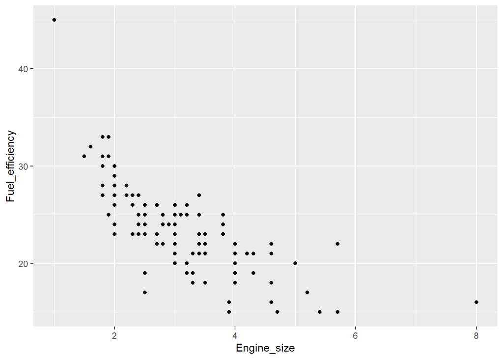

```r
ggplot(Car_sales, aes(x = Engine_size, y = Fuel_efficiency)) +
  geom_point() +
  labs(x = "Engine_size", y = "Fuel_efficiency")
```